# Plots

## Histograma

Frequência = Densidade

- densidade (número relativo)
- frequencia (quantidade)

```r
x = -10:10
cat("Dados: ")
```

```
Dados:
```

```r
print( sort( x**2) )
```

```
 [1]   0   1   1   4   4   9   9  16  16  25  25  36  36  49  49  64  64  81  81 100 100
```

```r
summary(x**2)
```

```
   Min. 1st Qu.  Median    Mean 3rd Qu.    Max.
   0.00    9.00   25.00   36.67   64.00  100.00
```

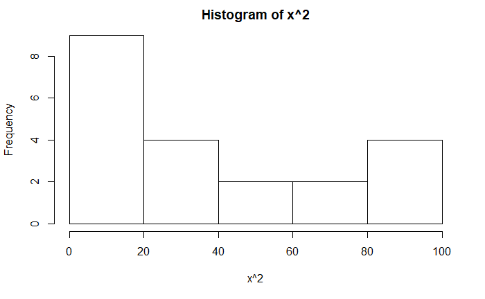

```r
hist(x**2)
```

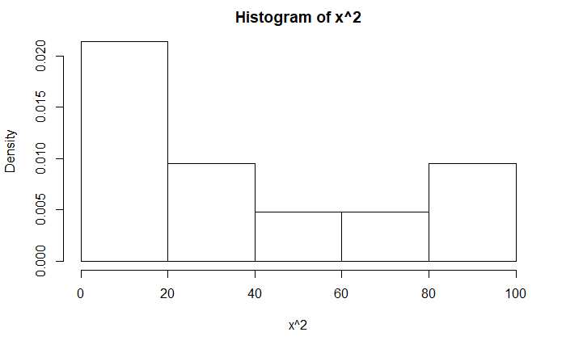

```r
hist(   x**2 , freq = F)
```

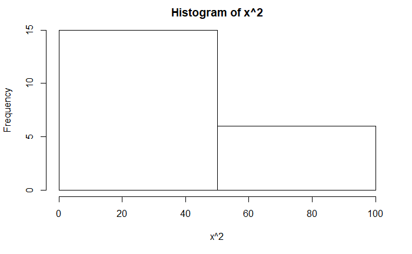

```r
hist(   x**2 , nclass = 2)
```

## Caixas (Box Plot)

```r
summary(airquality)
```

```
     Ozone           Solar.R           Wind             Temp           Month            Day
 Min.   :  1.00   Min.   :  7.0   Min.   : 1.700   Min.   :56.00   Min.   :5.000   Min.   : 1.0
 1st Qu.: 18.00   1st Qu.:115.8   1st Qu.: 7.400   1st Qu.:72.00   1st Qu.:6.000   1st Qu.: 8.0
 Median : 31.50   Median :205.0   Median : 9.700   Median :79.00   Median :7.000   Median :16.0
 Mean   : 42.13   Mean   :185.9   Mean   : 9.958   Mean   :77.88   Mean   :6.993   Mean   :15.8
 3rd Qu.: 63.25   3rd Qu.:258.8   3rd Qu.:11.500   3rd Qu.:85.00   3rd Qu.:8.000   3rd Qu.:23.0
 Max.   :168.00   Max.   :334.0   Max.   :20.700   Max.   :97.00   Max.   :9.000   Max.   :31.0
 NA's   :37       NA's   :7
```

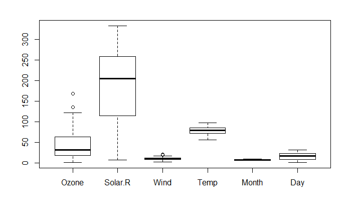

```r
boxplot( airquality )
```

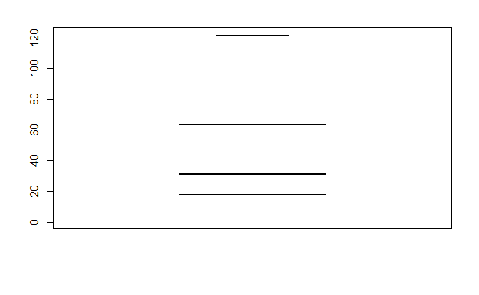

```r
boxplot( airquality$Ozone, outline = F )
```

## Exercicio - Basic Plot

Dataset airquality, medição de ozônio em MAIO

- Tentativa de utilizar o %>%

```r
airquality %>%
  filter( Month == 5 ) %>%
  select( Ozone ) %>%
  arrange(Ozone) %>%
  unlist() %>%
  plot()
```

```
Error in airquality %>% filter(Month == 5) %>% select(Ozone) %>% arrange(Ozone) %>%  :
  could not find function "%>%"
```

- Solução sem utilizar o %>%

```r
dados.filtrados <- filter(airquality, Month == 5)
```

```
Error in filter(airquality, Month == 5) : object 'Month' not found
```

## Exercício - BoxPlot

Existem apenas 5 meses no dataset Airquality Fazer um boxplot que permita uma avaliação mensal e comparativa do Ozônio

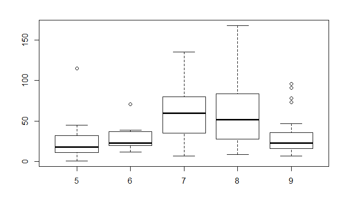

```r
#airquality$Ozone
#filter( airquality , Month == 5 ) %>% select( Ozone ) %>% arrange(Ozone)
#boxplot( data = airquality, formula = Ozone ~ Month  )
boxplot( Ozone ~ Month, data = airquality )
```

- Qual mês possui maior média de O3?
- Qual mês possui maior concentração de O3?
- Qual mês apresenta a menor variância de O3?
- E a maior?
- Qual o mês com a maior temperatura média?
- E qual tem a maior temperatura registrada?
- O mês com mais ventos é o mesmo mês que possui mais radiação solar?

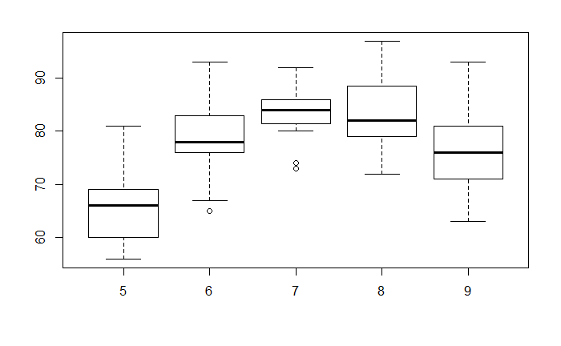

```r
boxplot( Temp ~ Month, data = airquality )
```

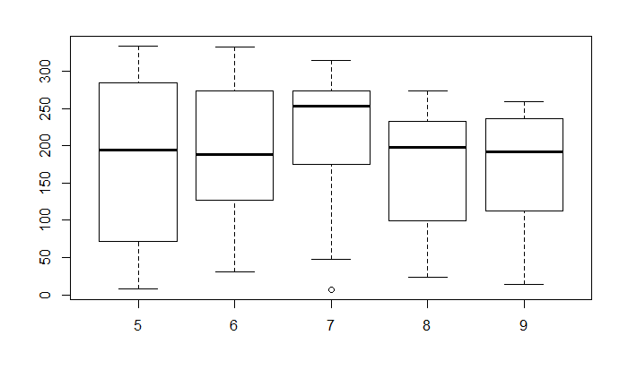

```r
boxplot( Solar.R ~ Month, data = airquality )
```

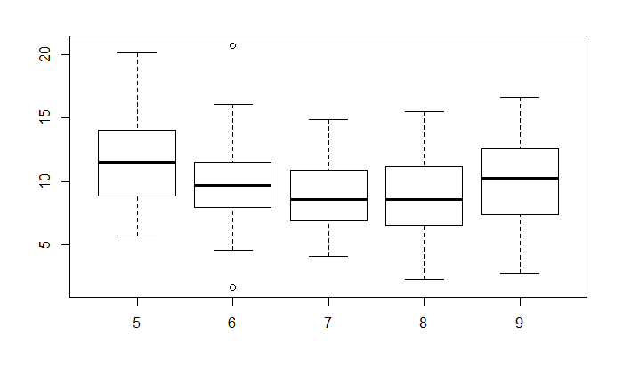

```r
boxplot( Wind ~ Month, data = airquality )
```

Teste 1

```r
var1 <- y ~ x+2
class(var1)
```

```
[1] "formula"
```

Teste 2

```r
var2 <- lm(airquality$Ozone~airquality$Month)
class(var2)
```

```
[1] "lm"
```

## Use o Plot Básico e responda:

Há alguma relação aparente entre concentração de ozônio e vento? Façam regressão linar com lm Desenhem a linha com lines()

```r
y.tend <- lm(data = airquality, formula = Ozone ~Wind)$coefficients
print(y.tend)
```

```
(Intercept)        Wind
  96.872895   -5.550923
```

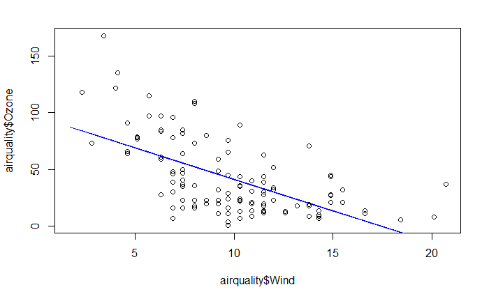

```r
x <- airquality$Wind
plot(x = airquality$Wind, y = airquality$Ozone)
lines(x = x, y = cbind(1, x) %*% y.tend, type = "l", col = "blue")
```

Depois desenhem a mesma linha com a função abline

```r
y.tend <- lm(data = airquality, formula = Ozone ~Wind)$coefficients
print(y.tend)
```

```
(Intercept)        Wind
  96.872895   -5.550923
```

[output not shown]

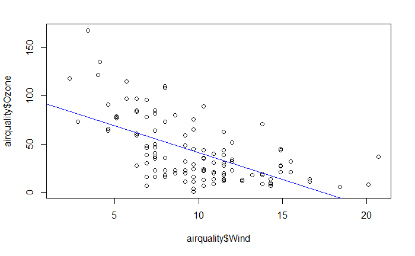

```r
x <- airquality$Wind
plot(x = airquality$Wind, y = airquality$Ozone)
abline(y.tend, type = "l", col = "blue")
```

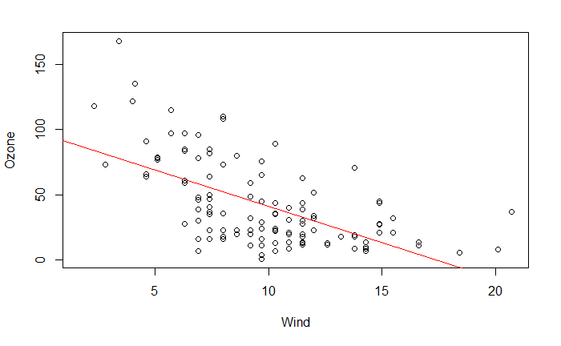

```r
with(airquality, plot(x = Wind, y = Ozone))
abline(lm(data = airquality, formula = Ozone ~Wind), col = "red")
```

Resposta Professor:

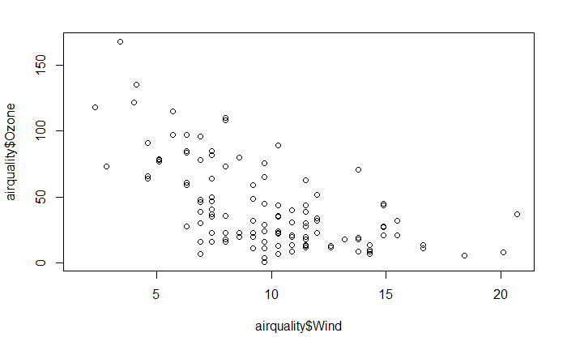

```r
plot(x = airquality$Wind, y = airquality$Ozone)
```

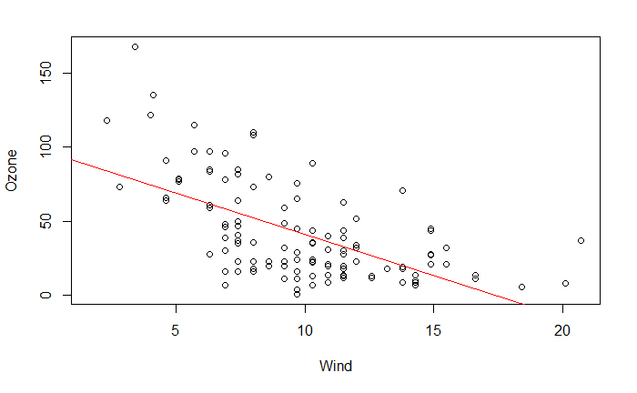

```r
with(airquality, plot(x = Wind, y = Ozone))
abline(lm(data = airquality, formula = Ozone ~Wind) , col='red')
```